# Assignment 2 - Movie Data

Julia Ferris

2023-09-13

# Importing Data

The data loaded for this document comes from the MySQL .CSV file saved after running the MySQL script.

```r
library(readr)
movies <- read_csv("C:/ProgramData/MySQL/MySQL Server 8.0/Uploads/movieFile1.csv", show_col_types = FALSE)
```

# Replacing NA Values

Some of the people included in the data set did not see the movies in the list. This missing data will be replaced in the section below by the average rating for the movie corresponding to the missing data entry. Table 1 shows the new values.

```r
movie1 <- c(movies$AvatarWater)
movie1 <- suppressWarnings(as.numeric(movie1, na.rm = TRUE))
movies$AvatarWater[movies$AvatarWater == "\\N"] <- round(mean(movie1, na.rm = TRUE))

movie2 <- c(movies$TopGunMaverick)
movie2 <- suppressWarnings(as.numeric(movie2, na.rm = TRUE))
movies$TopGunMaverick[movies$TopGunMaverick == "\\N"] <- round(mean(movie2, na.rm = TRUE))

movie3 <- c(movies$Oppenheimer)
movie3 <- suppressWarnings(as.numeric(movie3, na.rm = TRUE))
movies$Oppenheimer[movies$Oppenheimer == "\\N"] <- round(mean(movie3, na.rm = TRUE))

movie4 <- c(movies$SoundOfFreedom)
movie4 <- suppressWarnings(as.numeric(movie4, na.rm = TRUE))
movies$SoundOfFreedom[movies$SoundOfFreedom == "\\N"] <- round(mean(movie4, na.rm = TRUE))

movie5 <- c(movies$Barbie)
movie5 <- suppressWarnings(as.numeric(movie5, na.rm = TRUE))
movies$Barbie[movies$Barbie == "\\N"] <- round(mean(movie5, na.rm = TRUE))

movie6 <- c(movies$Boogeyman)
movie6 <- suppressWarnings(as.numeric(movie6, na.rm = TRUE))
movies$Boogeyman[movies$Boogeyman == "\\N"] <- round(mean(movie6, na.rm = TRUE))

library(gt)
gt(head(movies)) |>
  tab_header(
    title = "Table 1",
    subtitle = "Movie Ratings"
    )
```

Table 1

Movie Ratings

| person | AvatarWater | TopGunMaverick | Oppenheimer | SoundOfFreedom | Barbie | Boogeyman |
| --- | --- | --- | --- | --- | --- | --- |
| 1 | 3 | 4 | 4 | 4 | 2 | 4 |
| 2 | 4 | 5 | 4 | 5 | 4 | 2 |
| 3 | 4 | 3 | 4 | 5 | 4 | 5 |
| 4 | 5 | 5 | 3 | 5 | 3 | 4 |
| 5 | 5 | 4 | 4 | 5 | 3 | 4 |

# Research Questions

1. Which movie had the highest average rating?
2. Were movie ratings more consistent by person or by movie?
3. What percentage of ratings were greater than 3?

# 1: Which movie had the highest average rating?

To answer this question, the average rating for each movie was calculated. The average was based on the actual data plus the filled-in values.

```r
one <- mean(as.numeric(movies$AvatarWater))
two <- mean(as.numeric(movies$TopGunMaverick))
three <- mean(as.numeric(movies$Oppenheimer))
four <- mean(as.numeric(movies$SoundOfFreedom))
five <- mean(as.numeric(movies$Barbie))
six <- mean(as.numeric(movies$Boogeyman))

newdf <- data.frame(Avatar = one, TopGun = two, Opp = three, Sound = four, Barbie = five, Boogey = six)
newdf
```

```
##   Avatar TopGun Opp Sound Barbie Boogey
## 1    4.2    4.2 3.8   4.8    3.2    3.8
```

```r
max(newdf)
```

```
## [1] 4.8
```

# Answer 1:

Sound of Freedom had the highest average rating.

# 2: Were movie ratings more consistent by movie or by person?

To answer this question, bar graphs were created for each person. Then, bar graphs were created for each movie. The bar graphs were used for visual comparison. The standard deviation was calculated for each person and for each movie for numerical comparison.

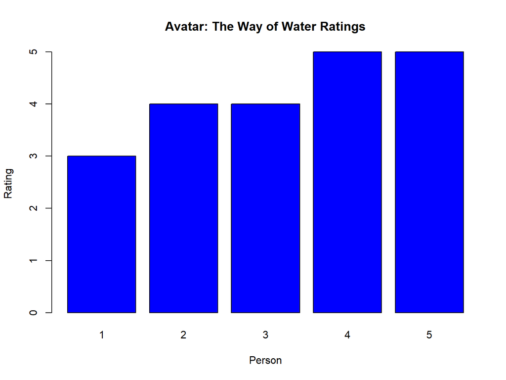

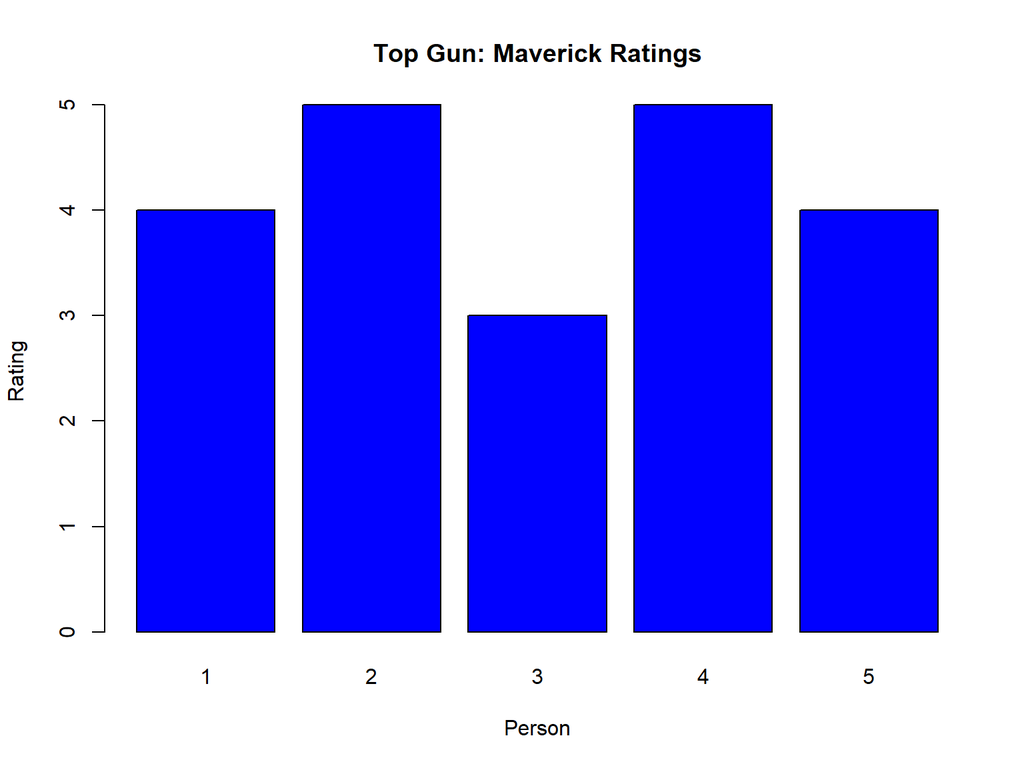

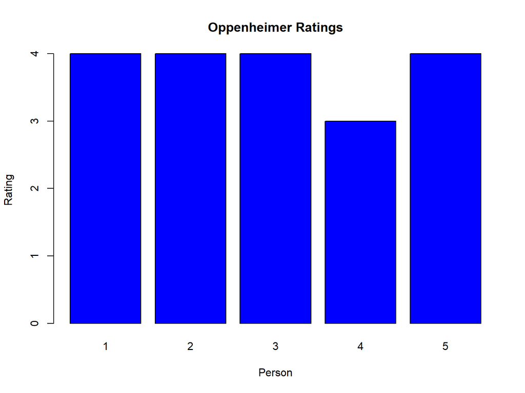

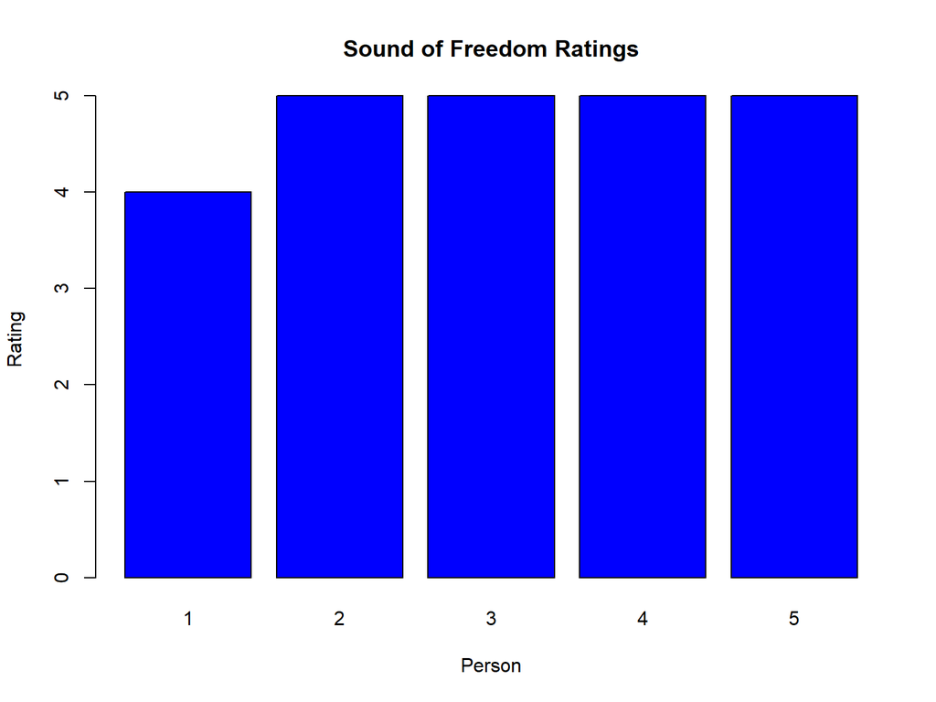

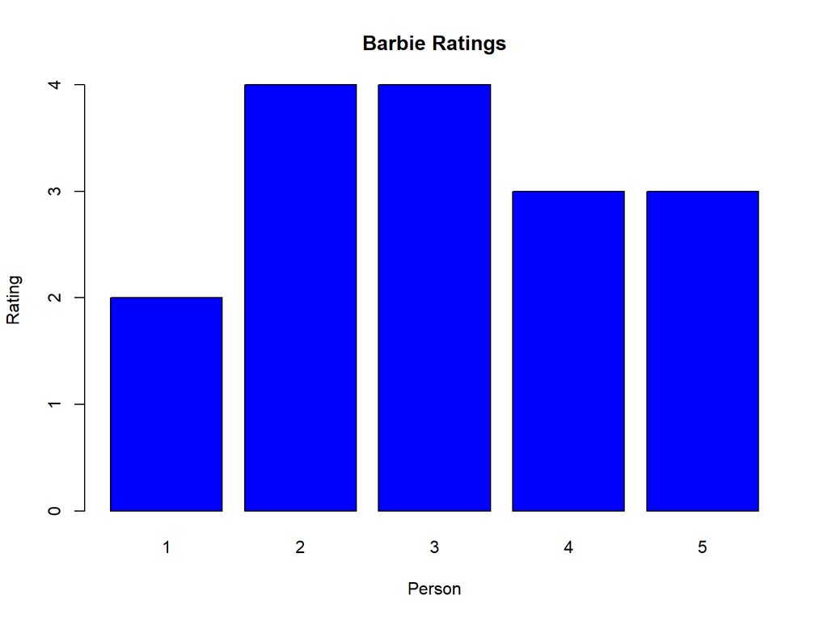

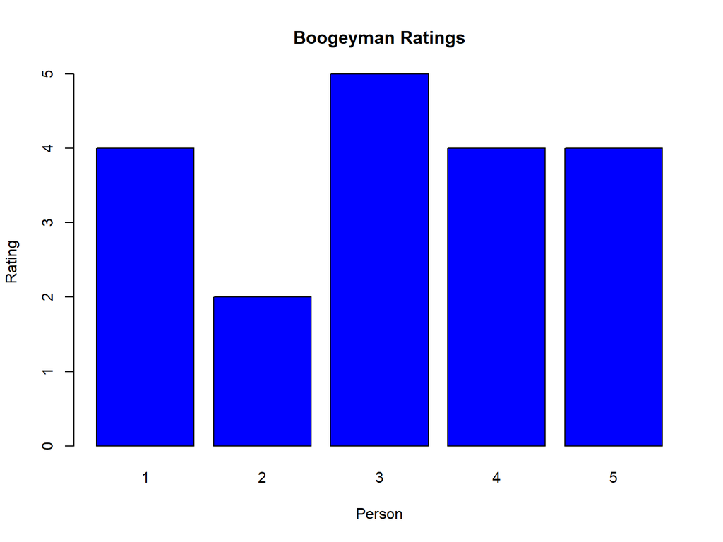

```r
barplot(as.numeric(movies$AvatarWater),xlab = "Person",ylab = "Rating",main = "Avatar: The Way of Water Ratings",names.arg = c(1, 2, 3, 4, 5), col="blue")
barplot(as.numeric(movies$TopGunMaverick),xlab = "Person",ylab = "Rating",main = "Top Gun: Maverick Ratings",names.arg = c(1, 2, 3, 4, 5), col="blue")
barplot(as.numeric(movies$Oppenheimer),xlab = "Person",ylab = "Rating",main = "Oppenheimer Ratings",names.arg = c(1, 2, 3, 4, 5), col="blue")
barplot(as.numeric(movies$SoundOfFreedom),xlab = "Person",ylab = "Rating",main = "Sound of Freedom Ratings",names.arg = c(1, 2, 3, 4, 5), col="blue")
barplot(as.numeric(movies$Barbie),xlab = "Person",ylab = "Rating",main = "Barbie Ratings",names.arg = c(1, 2, 3, 4, 5), col="blue")
barplot(as.numeric(movies$Boogeyman),xlab = "Person",ylab = "Rating",main = "Boogeyman Ratings",names.arg = c(1, 2, 3, 4, 5), col="blue")
```